# Class website reminder

[figure not shown]

[aub.ie/icb](https://phyletica.org/intro-to-comp-bio/)

## Today’s objectives

- [Linux ThinLinc: Log in and set up](https://phyletica.org/intro-to-comp-bio/thinlinc-intro.html)
- Intro to the command line shell (Bash)
- [Exercise 2](https://phyletica.org/intro-to-comp-bio/bash-exercise.html)

# Topic 2: Intro to Bash

- Most people communicate with their computer through graphical user interfaces (GUI)
- These GUIs are translators
  - Translates your clicks into instructions
- Works well for simple tasks, but does not scale well
  - E.g., what if you need to gather info from 1000 files?
  - Click, click, click …
- If you vacation in a foreign country, a translator is very helpful
- But, what if you move to that country for a job in which you interact with hundreds of people every day?
- A translator only gets you so far
- We want to learn the language used by the GUI to talk (more) directly to our computer

## About these slides

I will use a “Bash command line” heading for lines we type at the command prompt

```
Bash command line
```

```bash
echo "Hello World!"
```

I will use a “Bash script” heading for lines we type in a file

```
Bash script
```

```bash
echo "Hello World!"
```

# Anatomy of a command

```
Bash command line
```

```bash
echo -e "Hello, World!"
```

**`echo`**

Command (program)

**`-e`**

Option or “flag”

**`"Hello, World!"`**

Argument

Precision (spelling, case, and spaces) matters

```
Bash command line
```

```bash
echo - e "hello"
Echo "hello"
eco "hello"
```

## Getting help with a command

```
Bash command line
```

```bash
man echo
```

- This shows the manual for the `echo` command
- Navigate with arrow keys (or ‘j’/‘k’)
- Press ‘q’ to exit the manual
- Note, `man` is the command (program) and `echo` is an argument

# File System & Paths

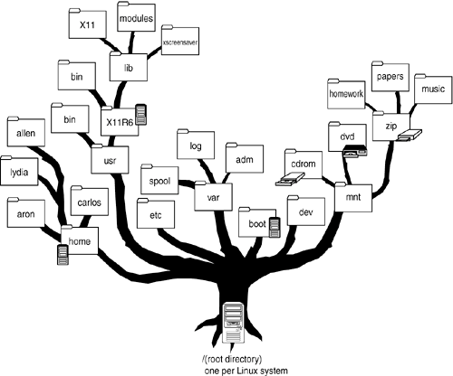

[flylib.com](https://flylib.com/books/en/1.295.1.47/1/)

```
Bash command line
```

```bash
pwd
ls /
ls /arc
ls /arc/homes/jro0014
ls
```

`pwd` shows the path to your current location in the file system (*p*rint *w*orking *d*irectory)

`ls` lists files and directories

Let’s make 2 new directories move into/out of them

```
Bash command line
```

```bash
mkdir foo bar
cd foo
pwd
cd ..
pwd
cd /arc/homes/jro0014/foo
pwd
cd ..
```

```
Bash command line
```

```bash
cd foo
pwd
cd ../bar # same as cd /arc/homes/jro0014/bar
```

How to get home?

- There are several ways

```
Bash command line
```

```bash
cd
pwd
cd ~
pwd
cd $HOME
pwd
```

`$HOME` and `~` are just variables for your home directory

```
Bash command line
```

```bash
echo $HOME
echo ~
```

You can use these variables for relative paths

```
Bash command line
```

```bash
cd foo
cd ~/bar # same as ../bar or /arc/homes/jro0014/bar
```

# What *are* commands?

- They are just programs!
  - Files on your computer that can be executed

`whereis` is a command for finding files in your `PATH`

```
Bash command line
```

```bash
whereis -b pwd
pwd
/bin/pwd
whereis -b ls
ls
/bin/ls
whereis -b whereis
```

- The reason you don’t have to type `/bin/pwd` is because `/bin` is in your `PATH`

```
Bash command line
```

```bash
echo $PATH
```

- When you type `pwd`, Bash will look for it in these directories

# For loop

```
Bash command line
```

```bash
for x in 1 2 3 4; do echo hello; done
```

```
Bash command line
```

```bash
for x in 1 2 3 4; do echo $x; done
```

Let’s make a file with one word in it

```
Bash command line
```

```bash
echo how > file1.txt
```

- “`>`” *redirects* the output of `echo` into the file “file1.txt”

Confirm the `file1.txt` exists and has “how” in it

```
Bash command line
```

```bash
ls
cat file1.txt
```

Let’s make 2 more files

```
Bash command line
```

```bash
echo are > file2.txt
echo you? > file3.txt
```

Let’s loop over the files and print their content

```
Bash command line
```

```bash
for f in file1.txt file2.txt file3.txt; do cat $f; done
```

We can use wildcards to make this easier

```
Bash command line
```

```bash
for f in file?.txt; do cat $f; done
```

- “`?`” will match any character at that position

```
Bash command line
```

```bash
for f in f*.txt; do cat $f; done
```

- “`f*.txt`” will match any file that starts with “f” and ends with “.txt”

# You are coding!

Let’s make a file and open it with a text editor

(I use VS Code below, but you can use any text editor)

```
Bash command line
```

```bash
touch my_bash_script.sh
code my_bash_script.sh
```

VS Code might open an authentication prompt; use your AU password

Add these lines to `my_bash_script.sh`

```
Bash script
```

```bash
echo "Hello, World!"

for x in 1 2 3 4; do echo $x; done
```

Save and close the `my_bash_script.sh` file

Now, you can run `my_bash_script.sh` as a script with Bash!

```
Bash command line
```

```bash
bash my_bash_script.sh
```

# How to do this on your computer?

Not required! But, if you want to use a Unix-like command line on your computer, you can!

## macOS users

You have a Terminal app already

- Open Spotlight, type “Terminal”, and press Return
- The default shell is Zsh (not Bash), but it is *very* similar

I recommend installing Xcode command line tools

- Open terminal and use this command:

  ```
  Zsh command line
  ```

  ```bash
  xcode-select --install
  ```

## Windows users

You can [install Linux via the Windows Subsystem for Linux (WSL)](https://learn.microsoft.com/en-us/windows/wsl/install)

I recommend you use the default Linux distribution (Ubuntu)

Running WSL will be very similar to Red Hat (ThinLinc)

# Resources

Here’s a nice lesson from Software Carpentries

http://swcarpentry.github.io/shell-novice/

# Acknowledgments

## Support

This work was made possible by funding provided to [Jamie Oaks](http://phyletica.org) from the National Science Foundation (DEB 1656004).